# Caso2

## Carga librerias

```r
# Cargar librerías necesarias
library(tidyverse)
library(broom)
library(car)
library(GGally)
library(performance)
```

```r
library(ggplot2)
```

## Cargar base de datos y EDA

```r
car_data <- read_csv("CAR DETAILS FROM CAR DEKHO.csv")
head(car_data)
```

```
## # A tibble: 6 × 8
##   name         year selling_price km_driven fuel  seller_type transmission owner
##   <chr>       <dbl>         <dbl>     <dbl> <chr> <chr>       <chr>        <chr>
## 1 Maruti 800…  2007         60000     70000 Petr… Individual  Manual       Firs…
## 2 Maruti Wag…  2007        135000     50000 Petr… Individual  Manual       Firs…
## 3 Hyundai Ve…  2012        600000    100000 Dies… Individual  Manual       Firs…
## 4 Datsun Red…  2017        250000     46000 Petr… Individual  Manual       Firs…
## 5 Honda Amaz…  2014        450000    141000 Dies… Individual  Manual       Seco…
## 6 Maruti Alt…  2007        140000    125000 Petr… Individual  Manual       Firs…
```

```r
dim(car_data)
```

```
## [1] 4340    8
```

```r
glimpse(car_data)
```

```
## Rows: 4,340
## Columns: 8
## $ name          <chr> "Maruti 800 AC", "Maruti Wagon R LXI Minor", "Hyundai Ve…
## $ year          <dbl> 2007, 2007, 2012, 2017, 2014, 2007, 2016, 2014, 2015, 20…
## $ selling_price <dbl> 60000, 135000, 600000, 250000, 450000, 140000, 550000, 2…
## $ km_driven     <dbl> 70000, 50000, 100000, 46000, 141000, 125000, 25000, 6000…
## $ fuel          <chr> "Petrol", "Petrol", "Diesel", "Petrol", "Diesel", "Petro…
## $ seller_type   <chr> "Individual", "Individual", "Individual", "Individual", …
## $ transmission  <chr> "Manual", "Manual", "Manual", "Manual", "Manual", "Manua…
## $ owner         <chr> "First Owner", "First Owner", "First Owner", "First Owne…
```

```r
summary(car_data)
```

```
##      name                year      selling_price       km_driven
##  Length:4340        Min.   :1992   Min.   :  20000   Min.   :     1
##  Class :character   1st Qu.:2011   1st Qu.: 208750   1st Qu.: 35000
##  Mode  :character   Median :2014   Median : 350000   Median : 60000
##                     Mean   :2013   Mean   : 504127   Mean   : 66216
##                     3rd Qu.:2016   3rd Qu.: 600000   3rd Qu.: 90000
##                     Max.   :2020   Max.   :8900000   Max.   :806599
##      fuel           seller_type        transmission          owner
##  Length:4340        Length:4340        Length:4340        Length:4340
##  Class :character   Class :character   Class :character   Class :character
##  Mode  :character   Mode  :character   Mode  :character   Mode  :character
##
##
##
```

## Limpieza de datos (basica)

```r
car_data <- car_data %>%
rename(
  nombre_carro = name,
  año = year,
  precio_vendido = selling_price,
  kms_recorridos = km_driven,
  combustible = fuel,
  vendedor = seller_type,
  transmisión = transmission,
  propietario = owner
)

## Eliminar filas duplicadas

car_data <- car_data %>%
distinct()

## Eliminar NA's

car_data <- car_data %>%
drop_na()


## Confirmar limpieza

glimpse(car_data)
```

```
## Rows: 3,577
## Columns: 8
## $ nombre_carro   <chr> "Maruti 800 AC", "Maruti Wagon R LXI Minor", "Hyundai V…
## $ año            <dbl> 2007, 2007, 2012, 2017, 2014, 2007, 2016, 2014, 2015, 2…
## $ precio_vendido <dbl> 60000, 135000, 600000, 250000, 450000, 140000, 550000, …
## $ kms_recorridos <dbl> 70000, 50000, 100000, 46000, 141000, 125000, 25000, 600…
## $ combustible    <chr> "Petrol", "Petrol", "Diesel", "Petrol", "Diesel", "Petr…
## $ vendedor       <chr> "Individual", "Individual", "Individual", "Individual",…
## $ transmisión    <chr> "Manual", "Manual", "Manual", "Manual", "Manual", "Manu…
## $ propietario    <chr> "First Owner", "First Owner", "First Owner", "First Own…
```

```r
colSums(is.na(car_data))
```

```
##   nombre_carro            año precio_vendido kms_recorridos    combustible
##              0              0              0              0              0
##       vendedor    transmisión    propietario
##              0              0              0
```

```r
## Vista final

head(car_data, 10)
```

```
## # A tibble: 10 × 8
##    nombre_carro           año precio_vendido kms_recorridos combustible vendedor
##    <chr>                <dbl>          <dbl>          <dbl> <chr>       <chr>
##  1 Maruti 800 AC         2007          60000          70000 Petrol      Individ…
##  2 Maruti Wagon R LXI …  2007         135000          50000 Petrol      Individ…
##  3 Hyundai Verna 1.6 SX  2012         600000         100000 Diesel      Individ…
##  4 Datsun RediGO T Opt…  2017         250000          46000 Petrol      Individ…
##  5 Honda Amaze VX i-DT…  2014         450000         141000 Diesel      Individ…
##  6 Maruti Alto LX BSIII  2007         140000         125000 Petrol      Individ…
##  7 Hyundai Xcent 1.2 K…  2016         550000          25000 Petrol      Individ…
##  8 Tata Indigo Grand P…  2014         240000          60000 Petrol      Individ…
##  9 Hyundai Creta 1.6 V…  2015         850000          25000 Petrol      Individ…
## 10 Maruti Celerio Gree…  2017         365000          78000 CNG         Individ…
## # ℹ 2 more variables: transmisión <chr>, propietario <chr>
```

```r
# Análisis de correlaciones

#Se seleccionan las variables numéricas relevantes
car_num <- car_data %>%
select(precio_vendido, año, kms_recorridos)
```

```r
#Calculamos matriz de correlación
cor_matrix <- cor(car_num, use = "complete.obs")
cor_matrix
```

```
##                precio_vendido        año kms_recorridos
## precio_vendido      1.0000000  0.4242601     -0.1873589
## año                 0.4242601  1.0000000     -0.4174898
## kms_recorridos     -0.1873589 -0.4174898      1.0000000
```

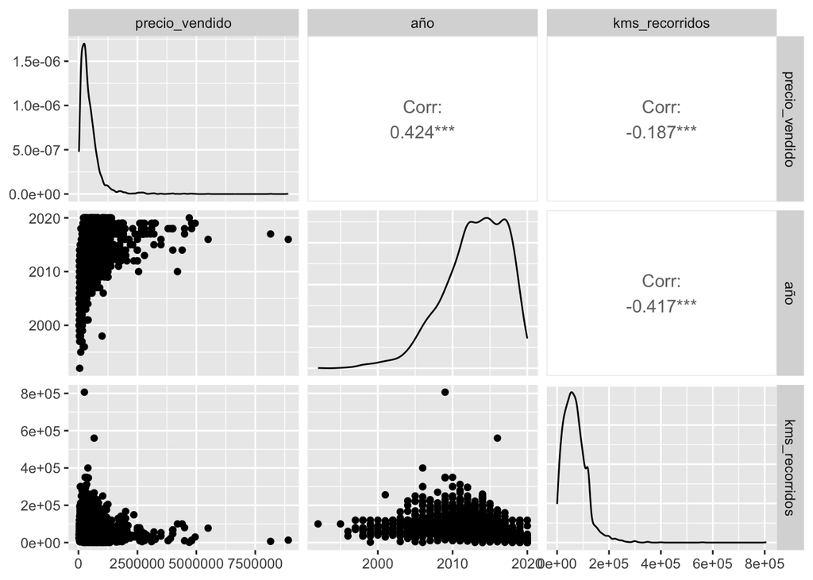

```r
# Visualización gráfica
GGally::ggpairs(car_num)
```

## Preguntas sección 1:

## ¿Qué variables muestran correlación fuerte o moderada con selling_price?

Se observa una correlación positiva entre precio de venta y año, lo que indica que los vehículos más nuevos tienden a venderse a precios más altos. Asimismo, se identifica una correlación negativa entre precio de venta y kilometraje, reflejando que los autos más usados tienden a valer menos.

## ¿Se observa correlación negativa entre km_driven y el precio? ¿Tiene sentido de mercado?

La correlación es negativa, lo que significa que conforme aumenta el kilometraje recorrido, el precio de venta disminuye. Este resultado tiene coherencia con la lógica de mercado, ya que un mayor uso implica mayor desgaste y menor valor de reventa.

## ¿A mayor antigüedad (menor year), disminuye el precio?

Se evidencia una relación positiva entre el año y el precio, lo que implica que los autos más antiguos tienden a tener precios más bajos. Esto es coherente con la depreciación natural de los vehículos a lo largo del tiempo.

## ¿Hay correlaciones cercanas a 0 (posible independencia lineal)?

No se observan correlaciones cercanas a cero entre las variables analizadas. Todas muestran algún grado de relación lineal, aunque de distinta magnitud, lo que indica que tanto la antigüedad como el uso influyen de forma significativa en el precio de venta.

```r
# Modelo lineal simple
modelo_simple <- lm(precio_vendido ~ kms_recorridos, data = car_data)
summary(modelo_simple)
```

```
##
## Call:
## lm(formula = precio_vendido ~ kms_recorridos, data = car_data)
##
## Residuals:
##     Min      1Q  Median      3Q     Max
## -553757 -268564 -112299  108350 8313276
##
## Coefficients:
##                  Estimate Std. Error t value Pr(>|t|)
## (Intercept)     6.128e+05  1.477e+04   41.48   <2e-16 ***
## kms_recorridos -2.006e+00  1.759e-01  -11.40   <2e-16 ***
## ---
## Signif. codes:  0 '***' 0.001 '**' 0.01 '*' 0.05 '.' 0.1 ' ' 1
##
## Residual standard error: 500400 on 3575 degrees of freedom
## Multiple R-squared:  0.0351, Adjusted R-squared:  0.03483
## F-statistic: 130.1 on 1 and 3575 DF,  p-value: < 2.2e-16
```

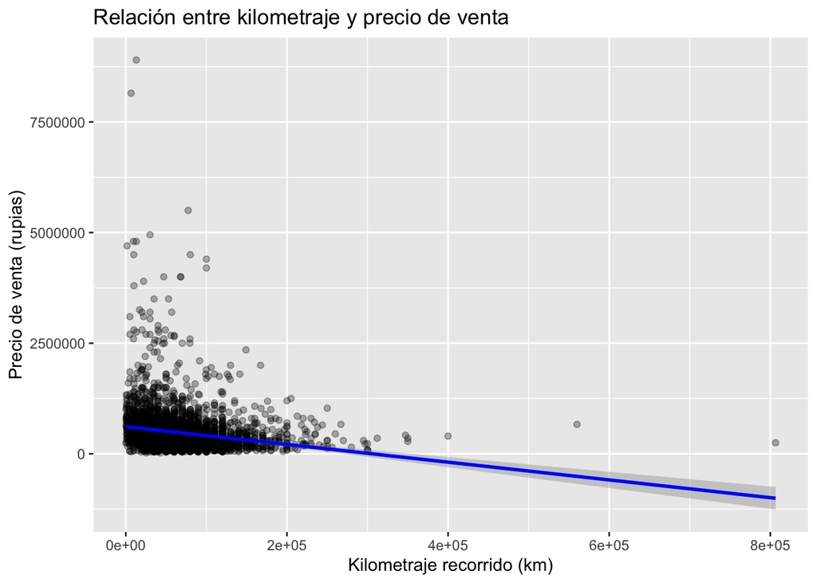

```r
# Visualización con línea de regresión
car_data %>%
ggplot(aes(x = kms_recorridos, y = precio_vendido)) +
geom_point(alpha = 0.3) +
geom_smooth(method = "lm", se = TRUE, color = "blue") +
labs(title = "Relación entre kilometraje y precio de venta",
x = "Kilometraje recorrido (km)", y = "Precio de venta (rupias)")
```

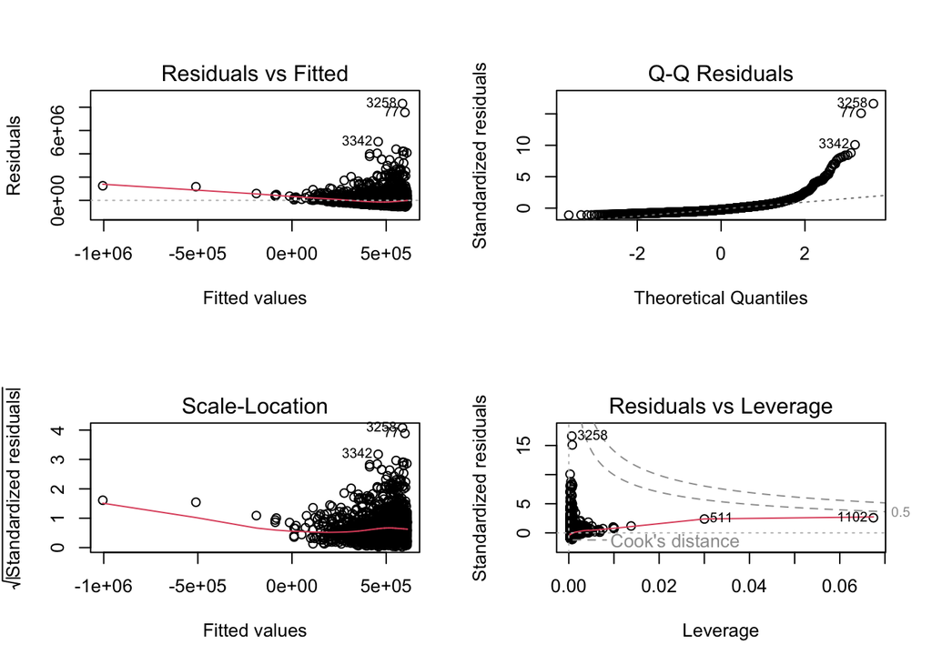

```r
# Diagnósticos del modelo
par(mfrow = c(2,2))
plot(modelo_simple)
```

```r
par(mfrow = c(1,1))
```

## Signo esperado y coherencia con la depreciación

El coeficiente estimado para km_driven es negativo, lo cual es coherente con la lógica económica, a medida que aumenta el kilometraje, el valor de venta disminuye. Esto refleja la depreciación derivada del uso del vehículo, ya que un mayor recorrido implica desgaste mecánico y menor vida útil.

## R²: proporción de variabilidad explicada por km_driven

El coeficiente de determinación (R²) del modelo es relativamente bajo, lo que significa que, aunque el kilometraje tiene un efecto significativo, no explica por sí solo la mayor parte de la variabilidad del precio.

## Verificación de supuestos del modelo

Linealidad: Los gráficos de dispersión muestran una tendencia descendente lineal, aunque con cierta dispersión en los valores altos de kilometraje.

Outliers e influencia: Las distancias de Cook identifican algunos puntos con influencia moderada, típicamente autos de lujo o con precios inusualmente altos respecto a su kilometraje, pero no afectan sustancialmente la validez general del modelo.

```r
#Regresión lineal múltiple
modelo_multiple <- lm(precio_vendido ~ kms_recorridos + año, data = car_data)
summary(modelo_multiple)
```

```
##
## Call:
## lm(formula = precio_vendido ~ kms_recorridos + año, data = car_data)
##
## Residuals:
##     Min      1Q  Median      3Q     Max
## -633158 -204944  -79802   63905 8266142
##
## Coefficients:
##                  Estimate Std. Error t value Pr(>|t|)
## (Intercept)    -1.006e+08  4.024e+06 -24.991   <2e-16 ***
## kms_recorridos -1.327e-01  1.784e-01  -0.744    0.457
## año             5.020e+04  1.997e+03  25.143   <2e-16 ***
## ---
## Signif. codes:  0 '***' 0.001 '**' 0.01 '*' 0.05 '.' 0.1 ' ' 1
##
## Residual standard error: 461300 on 3574 degrees of freedom
## Multiple R-squared:  0.1801, Adjusted R-squared:  0.1797
## F-statistic: 392.6 on 2 and 3574 DF,  p-value: < 2.2e-16
```

```r
# Comparación entre modelos
anova(modelo_simple, modelo_multiple)
```

```
## Analysis of Variance Table
##
## Model 1: precio_vendido ~ kms_recorridos
## Model 2: precio_vendido ~ kms_recorridos + año
##   Res.Df        RSS Df  Sum of Sq      F    Pr(>F)
## 1   3575 8.9501e+14
## 2   3574 7.6050e+14  1 1.3452e+14 632.17 < 2.2e-16 ***
## ---
## Signif. codes:  0 '***' 0.001 '**' 0.01 '*' 0.05 '.' 0.1 ' ' 1
```

```r
# Verificación de multicolinealidad
car::vif(modelo_multiple)
```

```
## kms_recorridos            año
##        1.21109        1.21109
```

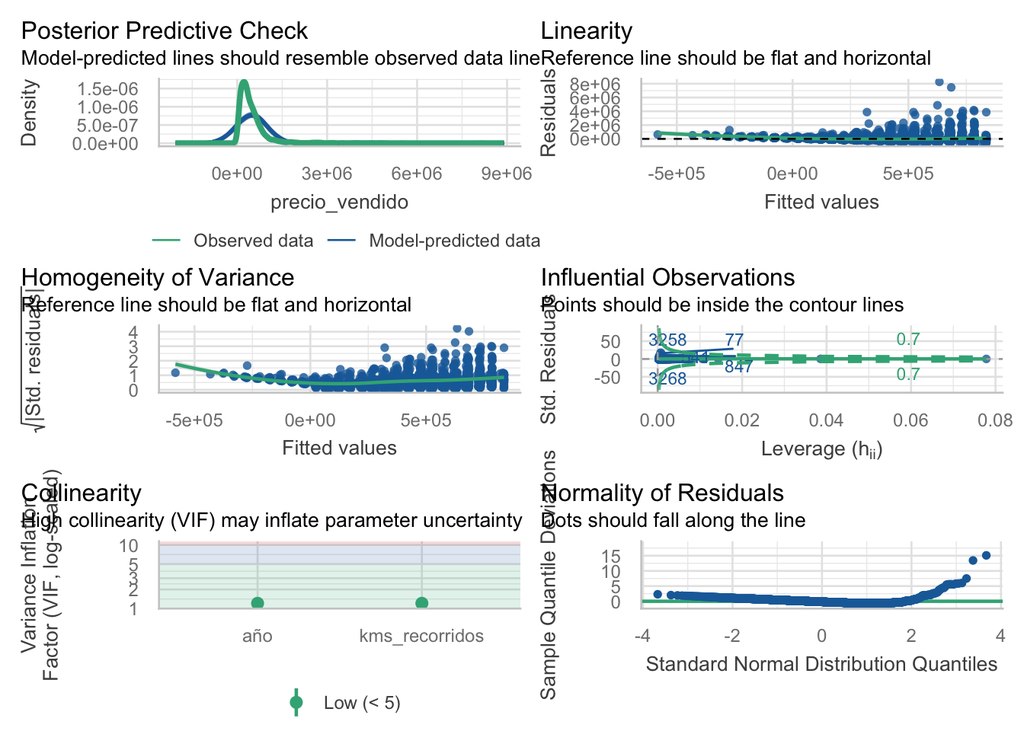

```r
#install.packages("see")
library(see)
# Diagnósticos
performance::check_model(modelo_multiple)
```

## Mejora de R² y R² ajustado respecto al modelo simple

El R² y el R² ajustado aumentan al pasar del modelo simple (solo con km_driven) al modelo múltiple (con km_driven y year).Esto evidencia que la inclusión del año mejora significativamente la capacidad explicativa del modelo, capturando una parte importante de la variabilidad del precio que el kilometraje por sí solo no lograba representar.

En términos de interpretación, el nuevo modelo predice mejor los precios de venta y ajusta de forma más adecuada la relación entre uso, antigüedad y valor.

## Coherencia de los signos con la lógica de mercado

Los signos estimados son coherentes con la teoría económica y con el funcionamiento del mercado de autos.

Coeficiente de year positivo: un auto más nuevo tiene mayor valor de reventa.

Coeficiente de km_driven negativo: a mayor kilometraje, mayor depreciación y menor precio.

## Chequeo de supuestos y VIF

No se detectan outliers altamente influyentes según la distancia de Cook.

En cuanto a la multicolinealidad, los valores del VIF para km_driven y year son menores a 5, por lo que no existe evidencia de colinealidad problemática. Esto implica que ambas variables aportan información independiente al modelo.

```r
#Prueba t
t_test_trans <- t.test(precio_vendido ~ transmisión, data = car_data)
t_test_trans
```

```
##
##  Welch Two Sample t-test
##
## data:  precio_vendido by transmisión
## t = 12.854, df = 314.26, p-value < 2.2e-16
## alternative hypothesis: true difference in means between group Automatic and group Manual is not equal to 0
## 95 percent confidence interval:
##   743254.6 1011924.1
## sample estimates:
## mean in group Automatic    mean in group Manual
##               1274955.1                397365.7
```

```r
#Promedios por grupo
car_data %>%
group_by(transmisión) %>%
summarise(media = mean(precio_vendido), sd = sd(precio_vendido), n = n())
```

```
## # A tibble: 2 × 4
##   transmisión    media       sd     n
##   <chr>          <dbl>    <dbl> <int>
## 1 Automatic   1274955. 1202846.   312
## 2 Manual       397366.  281297.  3265
```

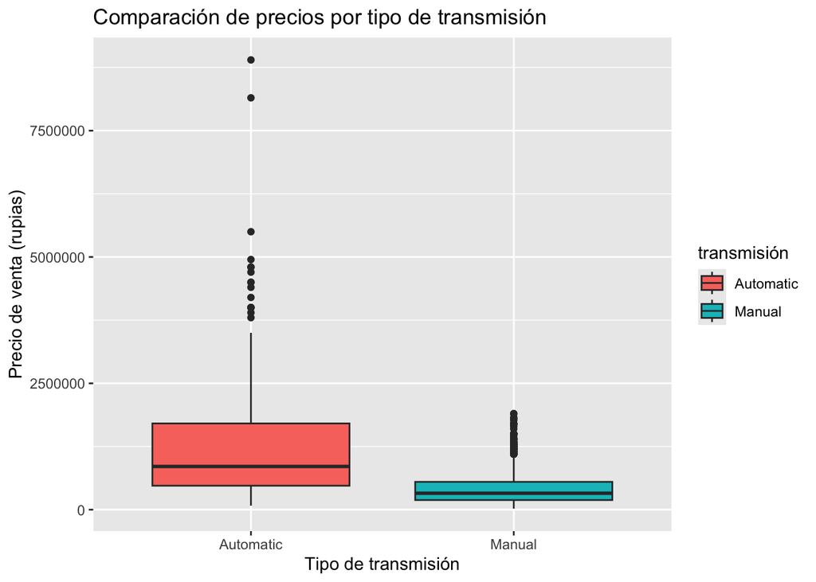

```r
ggplot(car_data, aes(x = transmisión, y = precio_vendido, fill = transmisión)) +
geom_boxplot() +
labs(title = "Comparación de precios por tipo de transmisión",
x = "Tipo de transmisión", y = "Precio de venta (rupias)")
```

## Análisis sección 4:

## ¿Existe diferencia significativa en el precio promedio?

La prueba t (en su versión de Welch, que no asume varianzas iguales) muestra un valor p < 0.05, lo que indica que existe una diferencia significativa en los precios promedio entre ambos grupos de transmisión. Se rechaza la hipótesis nula de igualdad de medias, concluyendo que el tipo de transmisión influye de manera significativa en el precio de venta de los automóviles usados.

## ¿Qué grupo presenta mayor precio promedio? Posibles razones de mercado

El análisis descriptivo revela que los vehículos automáticos presentan un precio promedio superior al de los vehículos con transmisión manual.

Esta diferencia puede explicarse por diversos factores de mercado:

1. Costo de producción y tecnología: Los sistemas automáticos suelen incorporar componentes electrónicos más complejos y costosos.
2. Comodidad y demanda: Los consumidores asocian la transmisión automática con mayor confort, especialmente en ciudades con tráfico denso.
3. Segmento del mercado: Los autos automáticos suelen pertenecer a gamas más altas o versiones mejor equipadas, lo que eleva su precio incluso en el mercado de segunda mano.

Por lo tanto, la diferencia no solo es significativa, sino también económicamente coherente con la realidad del mercado.

## Interpretación del valor p y tamaño del efecto

El valor p obtenido (p < 0.05) indica que la probabilidad de observar una diferencia tan grande en los precios entre transmisiones, si en realidad no existiera diferencia, es muy baja. Esto respalda la afirmación de que el tipo de transmisión afecta de forma real el precio de venta.

```r
#ANOVA

#Homogeneidad de varianzas
car::leveneTest(precio_vendido ~ combustible, data = car_data)
```

```
## Levene's Test for Homogeneity of Variance (center = median)
##         Df F value    Pr(>F)
## group    4  27.327 < 2.2e-16 ***
##       3572
## ---
## Signif. codes:  0 '***' 0.001 '**' 0.01 '*' 0.05 '.' 0.1 ' ' 1
```

```r
anova_fuel <- aov(precio_vendido ~ combustible, data = car_data)
summary(anova_fuel)
```

```
##               Df    Sum Sq   Mean Sq F value Pr(>F)
## combustible    4 7.182e+13 1.795e+13   74.94 <2e-16 ***
## Residuals   3572 8.558e+14 2.396e+11
## ---
## Signif. codes:  0 '***' 0.001 '**' 0.01 '*' 0.05 '.' 0.1 ' ' 1
```

```r
TukeyHSD(anova_fuel)
```

```
##   Tukey multiple comparisons of means
##     95% family-wise confidence level
##
## Fit: aov(formula = precio_vendido ~ combustible, data = car_data)
##
## $combustible
##                       diff        lwr       upr     p adj
## Diesel-CNG       340838.99   118985.3  562692.7 0.0002727
## Electric-CNG      36837.92 -1316917.2 1390593.0 0.9999931
## LPG-CNG         -101343.94  -460979.8  258291.9 0.9394801
## Petrol-CNG        62182.26  -159779.4  284143.9 0.9407005
## Electric-Diesel -304001.08 -1640195.9 1032193.7 0.9717865
## LPG-Diesel      -442182.94  -728716.7 -155649.2 0.0002513
## Petrol-Diesel   -278656.73  -323719.1 -233594.4 0.0000000
## LPG-Electric    -138181.86 -1504027.9 1227664.2 0.9987285
## Petrol-Electric   25344.34 -1310868.4 1361557.1 0.9999984
## Petrol-LPG       163526.20  -123091.1  450143.6 0.5252377
```

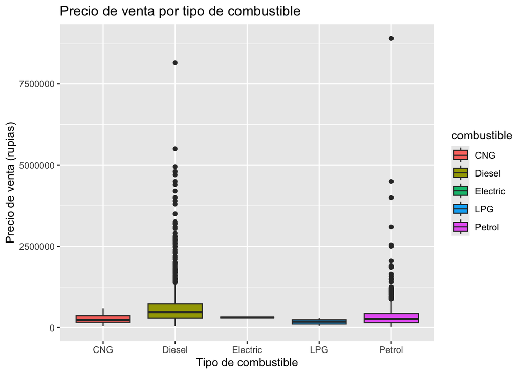

```r
ggplot(car_data, aes(x = combustible, y = precio_vendido, fill = combustible)) +
geom_boxplot() +
labs(title = "Precio de venta por tipo de combustible",
x = "Tipo de combustible", y = "Precio de venta (rupias)")
```

## Análisis sección 5:

## ¿Existen diferencias significativas entre tipos de combustible?

El resultado del análisis de varianza (ANOVA) muestra un valor p < 0.05, lo que indica que existen diferencias significativas en el precio promedio entre los distintos tipos de combustible.Por lo tanto, se rechaza la hipótesis nula de igualdad de medias, concluyendo que el tipo de combustible influye de forma significativa en el valor de reventa de los vehículos usados.

## ¿Qué tipo de combustible se asocia con precios más altos o bajos?

El análisis descriptivo y los diagramas de caja muestran que los vehículos diésel tienden a tener precios promedio más altos, seguidos por los automóviles de gasolina, mientras que los de CNG y LPG presentan precios inferiores. En algunos mercados, los vehículos eléctricos pueden tener precios más elevados, pero su frecuencia en el conjunto de datos es generalmente baja, lo que limita su influencia estadística en el ANOVA.

## ¿Qué comparaciones post hoc destacan?

Las pruebas post hoc de Tukey revelan diferencias significativas principalmente entre los siguientes pares de grupos:

-Diesel vs CNG / LPG: los autos diésel son significativamente más caros que los de gas.

Estas comparaciones confirman que los vehículos impulsados por combustibles alternativos (CNG y LPG) suelen ubicarse en los estratos más bajos de precio dentro del mercado de autos usados.

## Posibles explicaciones de mercado

Las diferencias en los precios por tipo de combustible pueden explicarse desde múltiples perspectivas económicas y técnicas:

1. Eficiencia y durabilidad: los motores diésel son más eficientes y duraderos, lo que justifica su mayor valor residual.
2. Demanda y preferencia del consumidor: la gasolina sigue siendo el combustible más extendido y con mayor aceptación general.
3. Costos y mantenimiento: los vehículos a gas (CNG y LPG) suelen tener menores costos operativos, pero su rendimiento y potencia pueden ser inferiores, reduciendo su atractivo de reventa.
4. Disponibilidad de infraestructura: la menor red de estaciones de carga o surtidores de gas limita la demanda de vehículos CNG/LPG, presionando sus precios a la baja.
5. Regulaciones ambientales: en algunos contextos, las restricciones a motores diésel o incentivos a vehículos eléctricos también modifican las valoraciones relativas.

## Conclusiones y recomendaciones finales

A partir de los resultados obtenidos en las cinco secciones del análisis estadístico del caso 2, se pueden plantear las siguientes recomendaciones finales para la empresa, orientadas tanto a la comprensión del mercado de autos como a la mejora de futuros modelos de valoración y estrategias de negocio:

El estudio confirma que el precio de los vehículos usados depende de factores técnicos (año, kilometraje) y comerciales (tipo de combustible, transmisión), los cuales interactúan con la lógica de depreciación y las preferencias del mercado.

Implementar modelos predictivos basados en estos resultados permitirá a AutoAnalytics CR ofrecer valoraciones más precisas, estrategias de segmentación más efectivas y diagnósticos de mercado más sólidos, fortaleciendo su posición como referente en el análisis de datos automotrices en la región.